# The simpson’s paradox

The simpson’s paradox

*A collection of common [dataviz caveats](https://www.data-to-viz.com/caveats.html) by [Data-to-Viz.com](https://www.data-to-viz.com)*

[figure not shown]

# Definition

> Simpson’s paradox, or the Yule–Simpson effect, is a phenomenon in probability and statistics, in which a trend appears in several different groups of data but disappears or reverses when these groups are combined. It is sometimes given the descriptive title reversal paradox or amalgamation paradox.

[Wikipedia](https://en.wikipedia.org/wiki/Simpson%27s_paradox)

# Example

Let’s consider the following [scatterplot](https://www.data-to-viz.com/graph/scatter.html) built from dummy data.

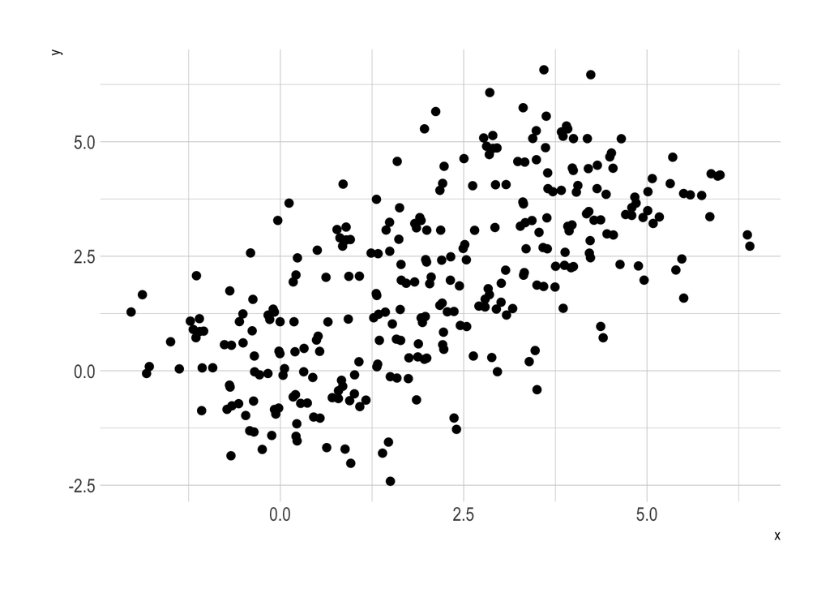

```r
# Libraries
library(tidyverse)
library(hrbrthemes)
library(babynames)
library(viridis)

# Create data
a <- data.frame( x = rnorm(100), y = rnorm(100)) %>% mutate(y = y-x/2)
b <- a %>% mutate(x=x+2) %>% mutate(y=y+2)
c <- a %>% mutate(x=x+4) %>% mutate(y=y+4)
data <- do.call(rbind, list(a,b,c))
data <- data %>% mutate(group=rep(c("A", "B", "C"), each=100))

ggplot(data, aes(x=x, y=y)) +
  geom_point( size=2) +
  theme_ipsum()
```

Here, it totally makes sense to state that there is a `positive correlation` between the X and the Y axis. Actually, the `Pearson` correlation coefficient is 0.63.

However, let’s check what happens if we consider the `groups` present in the dataset (3 groups):

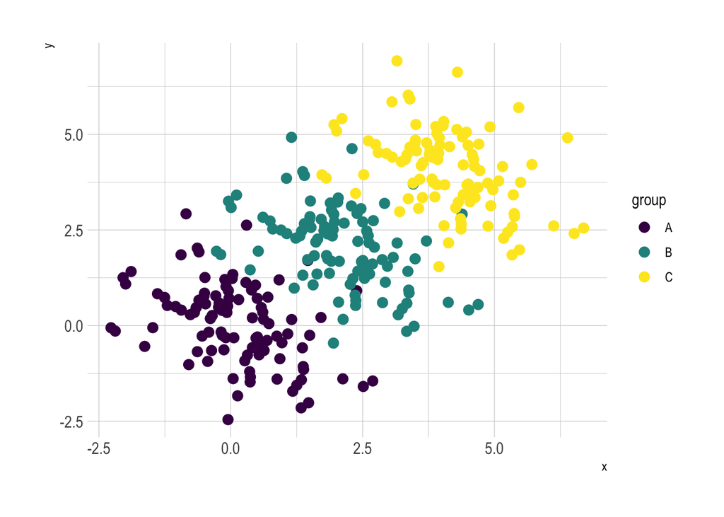

```r
# Libraries
library(tidyverse)
library(hrbrthemes)
library(babynames)
library(viridis)

# Create data
a <- data.frame( x = rnorm(100), y = rnorm(100)) %>% mutate(y = y-x/2)
b <- a %>% mutate(x=x+2) %>% mutate(y=y+2)
c <- a %>% mutate(x=x+4) %>% mutate(y=y+4)
data <- do.call(rbind, list(a,b,c))
data <- data %>% mutate(group=rep(c("A", "B", "C"), each=100))

ggplot(data, aes(x=x, y=y, color=group)) +
  geom_point( size=3) +
  scale_color_viridis(discrete=TRUE) +
  theme_ipsum()
```

Here, we understand that the positive correlation was due to a difference `between groups`. Actually, the correlation coefficient is even negative if each group is considered separately.

This is the Sympson’s paradox: the trend between two different variables reverses when a third variable is included.

# Impact on dataviz

The impact is strong for data analytics and dataviz. The Simpson’s paradox can lead to a wrong conclusions with spurious correlation. Always double check the potential effect of confounding variables available in your dataset.

# Going further

- Simpson’s Paradox - Correlations and Slopes. By [Prof. Eric A. Suess](http://rstudio-pubs-static.s3.amazonaws.com/155188_cc8b400f7d134a3e9de6cbfb8320e1e0.html). It gives a nice real life example based on book price and number of pages in books.
- The [Wikipedia](https://en.wikipedia.org/wiki/Simpson%27s_paradox) page

# Comments

Any thoughts on this? Found any mistake? Disagree? Please drop me a word on [twitter](https://twitter.com/R_Graph_Gallery) or in the comment section below:

A work by [Yan Holtz](https://github.com/holtzy/) for data-to-viz.com